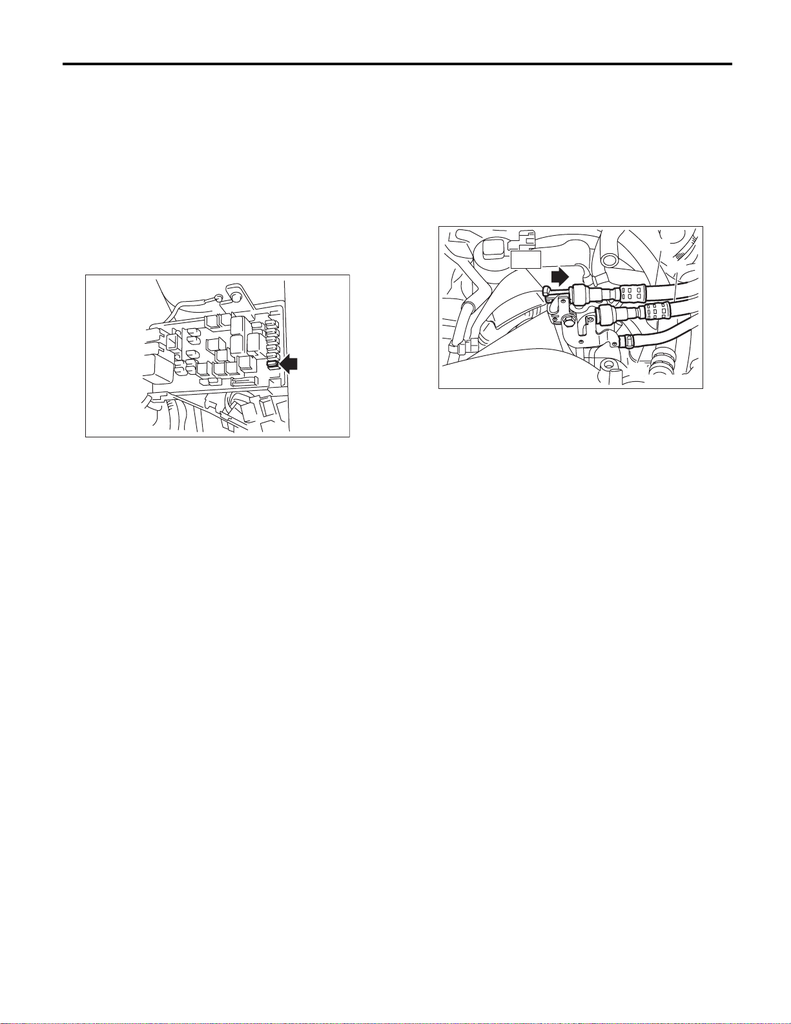

Fuel

FUEL INJECTION (FUEL SYSTEMS)

25.Fuel

A: PROCEDURE

1. RELEASING OF FUEL PRESSURE

WARNING:

working area.

CAUTION:

Be careful not to spill fuel.

1) Remove the fuse of fuel pump from main fuse

box.

2) Start the engine and run it until it stalls.

3) After the engine stalls, crank it for five more sec-

onds.

4) Turn the ignition switch to OFF.

5) Install the fuse of fuel pump to the main fuse box.

2. DRAINING FUEL (WITH SUBARU SE-

LECT MONITOR)

WARNING:

Place “NO OPEN FLAMES” signs near the

working area.

CAUTION:

Be careful not to spill fuel.

NOTE:

• If the fuel pump cannot be driven, refer to the

procedures for draining from the fuel filler hose.

<Ref. to FU(STI)-65, DRAINING FUEL

(THROUGH THE FUEL FILLER HOSE), PROCE-

DURE, Fuel.>

• Be careful not to let the battery run-out.

• Be aware that the fuel may remain in the fuel

tank after draining the fuel.

1) Release the fuel pressure. <Ref. to FU(STI)-64,

RELEASING OF FUEL PRESSURE, PROCE-

DURE, Fuel.>

2) Attach ST to the fuel delivery pipe and push ST

in the direction of arrow mark to disconnect the fuel

delivery hose.

ST 42099AE000 QUICK CONNECTOR RE-

LEASE

CAUTION:

• Be careful not to spill fuel.

• Catch the fuel from hoses using a container

or cloth.

3) Connect ST to the fuel delivery hose.

ST 18471AA000 FUEL PIPE ADAPTER

4) Connect the gasoline proof hose to ST and put

the end of the hose in the container.

5) Drive the fuel pump and drain the fuel using Sub-

aru Select Monitor. <Ref. to EN(STI)(diag)-60, OP-

ERATION, System Operation Check Mode.>

CAUTION:

Be careful not to spill fuel.

6) Install the related parts in the reverse order after

draining the fuel.

FU-01122

(A) Fuel delivery hose

(B) Fuel return hose

(C) Evaporation hose

ME-05008

(A)

(B)

ST

(C)

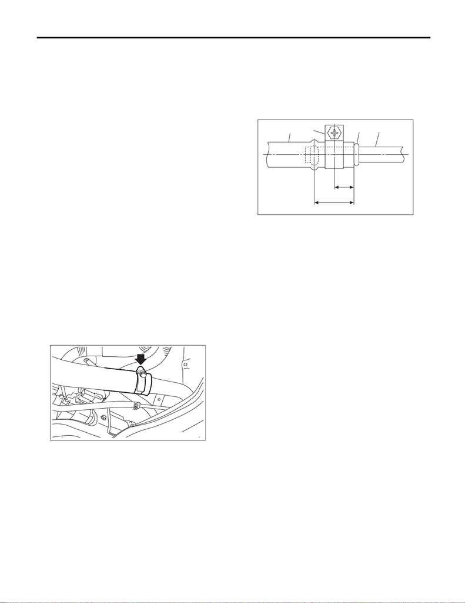

Fuel

FUEL INJECTION (FUEL SYSTEMS)

3. DRAINING FUEL (THROUGH THE FUEL

FILLER HOSE)

WARNING:

Place “NO OPEN FLAMES” signs near the

working area.

CAUTION:

• Be careful not to spill fuel.

• Fuel may remain in the fuel filler pipe. Drain

the fuel from the fuel filler pipe through the fill

opening using the gasoline proof pump and the

gasoline proof hose (ø10 or less) before the op-

eration.

NOTE:

Be aware that the fuel may remain in the fuel tank

after draining the fuel.

1) Lift up the vehicle.

2) Open the fuel filler lid and remove the fuel filler

cap.

NOTE:

This operation is required to release the inner pres-

sure of the fuel tank.

3) Drain the fuel from the fuel filler pipe through the

filler opening using the gasoline proof pump and

the gasoline proof hose (ø10 or less).

4) Disconnect the fuel filler hose from the fuel filler

pipe assembly.

CAUTION:

• Be careful not to spill fuel.

• Catch the fuel from hoses using a container

or cloth.

5) Set the container under the vehicle and insert

the gasoline proof hose (ø10 or less) into the fuel

filler hose to drain the fuel.

CAUTION:

Be careful not to spill fuel.

6) Install the related parts in the reverse order after

draining the fuel.

NOTE:

Correctly insert the fuel filler hose to the spool, and

then install the clamp as shown.

Tightening torque:

2.5 N·m (0.3 kgf-m, 1.8 ft-lb)

FU-08349

(1) Fuel filler hose

(2) Clamp

(3) Spool

(4) Fuel filler pipe

FU-05815

(1)

(2)

(4)

L

L/2

(3)